# 重賞レース予測レポート【毎時自動更新中】

作成日時: 2025/11/21 15:04:01

☞ [マニュアル(pdf)](https://ryutoro-galois.github.io/keiba-predictor/manual/manual.pdf)

☞ 過去5年の同一レース結果: [2024年](https://ryutoro-galois.github.io/keiba-predictor/report/PredResult_2024y_raceDate_20241116_20241117.html), [2023年](https://ryutoro-galois.github.io/keiba-predictor/report/PredResult_2023y_raceDate_20231118_20231119.html), [2022年](https://ryutoro-galois.github.io/keiba-predictor/report/PredResult_2022y_raceDate_20221119_20221120.html), [2021年](https://ryutoro-galois.github.io/keiba-predictor/report/PredResult_2021y_raceDate_20211120_20211121.html), [2020年](https://ryutoro-galois.github.io/keiba-predictor/report/PredResult_2020y_raceDate_20201122_20201123.html)

☞ 過去4週間の別レース結果: [1週前(11/15-16)](https://ryutoro-galois.github.io/keiba-predictor/report/PredResult_2025y_raceDate_20251115_20251116.html), [2週前(11/8-9)](https://ryutoro-galois.github.io/keiba-predictor/report/PredResult_2025y_raceDate_20251108_20251109.html), [3週前(11/1-2)](https://ryutoro-galois.github.io/keiba-predictor/report/PredResult_2025y_raceDate_20251101_20251102.html), [4週前(10/25-26)](https://ryutoro-galois.github.io/keiba-predictor/report/PredResult_2025y_raceDate_20251025_20251026.html)

☞ netkeiba: [福島記念(GⅢ)](https://race.netkeiba.com/race/shutuba.html?race_id=202503030511&rf=race_list), [マイルチャンピオンシップ(GⅠ)](https://race.netkeiba.com/race/shutuba.html?race_id=202508040611&rf=race_list), [東京スポーツ杯2歳ステークス(GⅡ)](https://race.netkeiba.com/race/shutuba.html?race_id=202505050611&rf=race_list)

## 0. 推し馬予測 (AI予測)

### 【福島記念(GⅢ) 2025/11/22(土)】

- 本命(◎): 1-3着内確率(勝負強さ)が1位の馬
- 対抗(◯): 1-3着内確率が2-N位(20%程度以上)の中で予測タイムが最も速い馬
- 3番手(▲): 1-3着内確率が2-N位(20%程度以上)のでダークホース確率が最も高い馬
- 穴: ダークホース確率が上位1-M位(40%程度以上)の中で1-3着内確率が最も高い馬

| 推し馬 | 枠番 | 馬番 | 人気 | オッズ | 馬名 | 騎手 | 調教師 | 予測タイム(sec) | 1_順位 | 1-3着内確率(%) | 2_順位 | ﾀﾞｰｸﾎｰｽ確率(%) | 3_順位 |
| --- | --- | --- | --- | --- | --- | --- | --- | --- | --- | --- | --- | --- | --- |
| 本命(◎) | 4 | 8 | 2 | 5.4 | エコロヴァルツ | Ａ．プーシャン | 牧浦充徳 | 117.3 | 3.5 | 25.1 | 1 | 0.6 | 12 |
| 対抗(◯) | 1 | 1 | 1 | 5.3 | クリスマスパレード | 戸崎圭太 | 加藤士津八 | 117.3 | 3.5 | 21.1 | 4 | 0.6 | 14 |
| 3番手(▲) | 5 | 10 | 3 | 5.8 | ニシノティアモ | 津村明秀 | 上原佑紀 | 130.0 | 9.0 | 23.0 | 3 | 0.6 | 13 |
| 穴 | 2 | 3 | 10 | 19.7 | クリノメイ | 酒井学 | 須貝尚介 | 129.5 | 7.0 | 11.6 | 6 | 55.7 | 1 |

### 【マイルチャンピオンシップ(GⅠ) 2025/11/23(日)】

- 本命(◎): 1-3着内確率(勝負強さ)が1位の馬
- 対抗(◯): 1-3着内確率が2-N位(20%程度以上)の中で予測タイムが最も速い馬
- 3番手(▲): 1-3着内確率が2-N位(20%程度以上)のでダークホース確率が最も高い馬
- 穴: ダークホース確率が上位1-M位(40%程度以上)の中で1-3着内確率が最も高い馬

| 推し馬 | 枠番 | 馬番 | 人気 | オッズ | 馬名 | 騎手 | 調教師 | 予測タイム(sec) | 1_順位 | 1-3着内確率(%) | 2_順位 | ﾀﾞｰｸﾎｰｽ確率(%) | 3_順位 |
| --- | --- | --- | --- | --- | --- | --- | --- | --- | --- | --- | --- | --- | --- |
| 本命(◎) | 3 | 5 | 3 | 7.4 | アスコリピチェーノ | Ｃ．ルメール | 黒岩陽一 | 92.0 | 2 | 28.3 | 1 | 3.3 | 13 |
| 対抗(◯) | 7 | 15 | 1 | 2.1 | ジャンタルマンタル | 川田将雅 | 高野友和 | 91.5 | 1 | 22.0 | 4 | 4.4 | 11 |
| 3番手(▲) | 4 | 7 | 9 | 24.7 | チェルヴィニア | Ｔ．マーカンド | 木村哲也 | 94.6 | 6 | 20.4 | 6 | 5.4 | 9 |
| 穴 | 2 | 4 | 10 | 26.9 | マジックサンズ | 武豊 | 須貝尚介 | 92.8 | 3 | 12.7 | 9 | 54.1 | 4 |

## 1. 予測チャート (タイム/勝負強さ)

### 【福島記念(GⅢ)】

2025/11/22(土), 03_福島, 芝右2000m

[interactive chart not shown]

### 【マイルチャンピオンシップ(GⅠ)】

2025/11/23(日), 08_京都, 芝右外1600m

[interactive chart not shown]

## 2. オッズモニタリング (毎時)

### 【福島記念】

[interactive chart not shown]

### 【マイルチャンピオンシップ】

[interactive chart not shown]

## 3. 出馬表

### 【福島記念 2025/11/22(土) 】

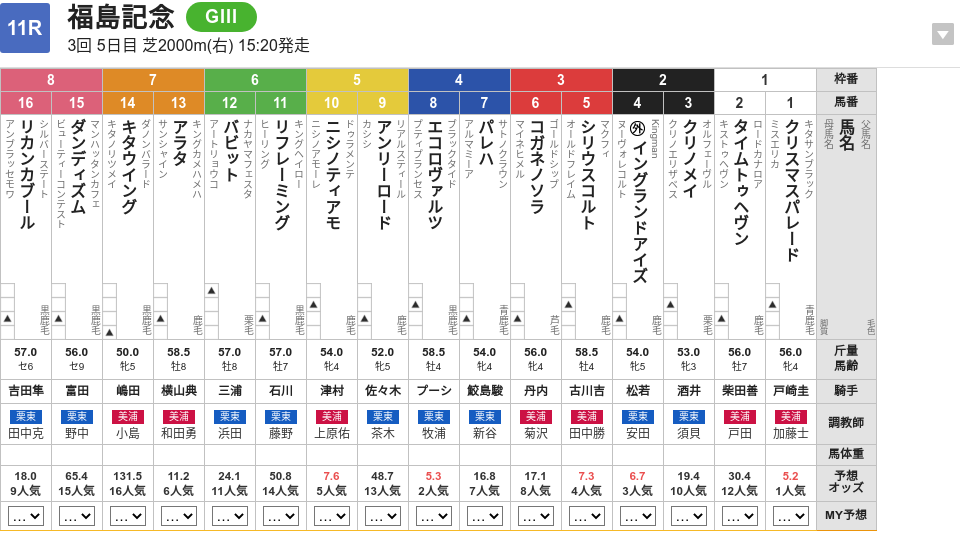

### 【マイルチャンピオンシップ 2025/11/23(日) 】

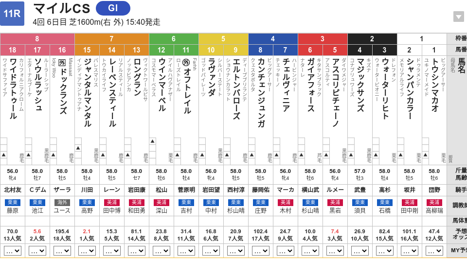

### 【東京スポーツ杯2歳ステークス 2025/11/24(月) 】

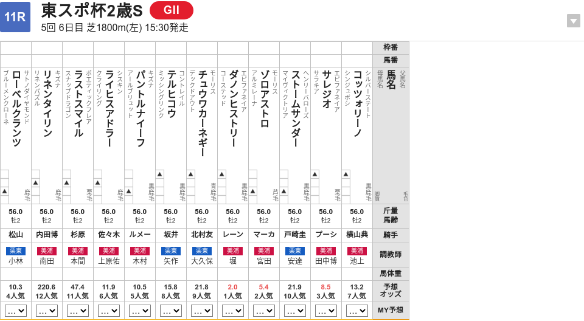

## 4. 単勝予測結果

### 【福島記念(GⅢ) 2025/11/22(土)】

| 枠番 | 馬番 | 人気 | オッズ | 馬名 | 騎手 | 調教師 | 予測タイム(sec) | 1_順位 | 1-3着内確率(%) | 2_順位 | ﾀﾞｰｸﾎｰｽ確率(%) | 3_順位 |
| --- | --- | --- | --- | --- | --- | --- | --- | --- | --- | --- | --- | --- |
| 1 | 1 | 1 | 5.3 | クリスマスパレード | 戸崎圭太 | 加藤士津八 | 117.3 | 3.5 | 21.1 | 4 | 0.6 | 14 |
| 1 | 2 | 12 | 30.8 | タイムトゥヘヴン | 柴田善臣 | 戸田博文 | 117.3 | 3.5 | 4.7 | 13 | 23.6 | 3 |
| 2 | 3 | 10 | 19.7 | クリノメイ | 酒井学 | 須貝尚介 | 129.5 | 7.0 | 11.6 | 6 | 55.7 | 1 |
| 2 | 4 | 4 | 6.8 | イングランドアイズ | 松若風馬 | 安田翔伍 | 132.7 | 13.0 | 18.6 | 5 | 0.5 | 16 |
| 3 | 5 | 5 | 7.5 | シリウスコルト | 古川吉洋 | 田中勝春 | 131.2 | 11.0 | 24.0 | 2 | 0.6 | 15 |
| 3 | 6 | 8 | 17.4 | コガネノソラ | 丹内祐次 | 菊沢隆徳 | 129.6 | 8.0 | 9.0 | 8 | 2.2 | 9 |
| 4 | 7 | 7 | 17.0 | パレハ | 鮫島克駿 | 新谷功一 | 132.1 | 12.0 | 9.0 | 9 | 1.3 | 11 |
| 4 | 8 | 2 | 5.4 | エコロヴァルツ | Ａ．プーシャン | 牧浦充徳 | 117.3 | 3.5 | 25.1 | 1 | 0.6 | 12 |
| 5 | 9 | 13 | 49.4 | アンリーロード | 佐々木大輔 | 茶木太樹 | 134.1 | 15.0 | 5.1 | 12 | 12.7 | 8 |
| 5 | 10 | 3 | 5.8 | ニシノティアモ | 津村明秀 | 上原佑紀 | 130.0 | 9.0 | 23.0 | 3 | 0.6 | 13 |

[output cut: 6 more lines]

### 【マイルチャンピオンシップ(GⅠ) 2025/11/23(日)】

| 枠番 | 馬番 | 人気 | オッズ | 馬名 | 騎手 | 調教師 | 予測タイム(sec) | 1_順位 | 1-3着内確率(%) | 2_順位 | ﾀﾞｰｸﾎｰｽ確率(%) | 3_順位 |
| --- | --- | --- | --- | --- | --- | --- | --- | --- | --- | --- | --- | --- |
| 1 | 1 | 12 | 47.4 | トウシンマカオ | 団野大成 | 高柳瑞樹 | 99.5 | 12 | 12.0 | 10 | 20.4 | 8 |
| 1 | 2 | 16 | 101.1 | シャンパンカラー | 坂井瑠星 | 田中剛 | 99.9 | 13 | 17.6 | 7 | 23.2 | 7 |
| 2 | 3 | 15 | 82.4 | ウォーターリヒト | 高杉吏麒 | 石橋守 | 99.1 | 10 | 4.2 | 17 | 68.0 | 1 |
| 2 | 4 | 10 | 26.9 | マジックサンズ | 武豊 | 須貝尚介 | 92.8 | 3 | 12.7 | 9 | 54.1 | 4 |
| 3 | 5 | 3 | 7.4 | アスコリピチェーノ | Ｃ．ルメール | 黒岩陽一 | 92.0 | 2 | 28.3 | 1 | 3.3 | 13 |
| 3 | 6 | 4 | 10.0 | ガイアフォース | 横山武史 | 杉山晴紀 | 100.7 | 17 | 20.5 | 5 | 2.3 | 15 |
| 4 | 7 | 9 | 24.7 | チェルヴィニア | Ｔ．マーカンド | 木村哲也 | 94.6 | 6 | 20.4 | 6 | 5.4 | 9 |
| 4 | 8 | 17 | 102.4 | カンチェンジュンガ | 藤岡佑介 | 庄野靖志 | 99.0 | 9 | 4.8 | 16 | 49.5 | 5 |
| 5 | 9 | 7 | 20.9 | エルトンバローズ | 西村淳也 | 杉山晴紀 | 98.2 | 8 | 11.8 | 12 | 2.9 | 14 |
| 5 | 10 | 6 | 16.8 | ラヴァンダ | 岩田望来 | 中村直也 | 99.9 | 14 | 15.1 | 8 | 4.0 | 12 |

[output cut: 7 more lines]

## 5. 人気と着順の乖離率推移

### 【福島記念_1990y_2019y】

[interactive chart not shown]

### 【マイルチャンピオンシップ_1990y_2019y】

[interactive chart not shown]

### 【東京スポーツ杯2歳ステークス_2001y_2019y】

[interactive chart not shown]

### 【福島記念_1990y_2019y】

| No | 開催年 | 不整合率(%) | 頭数 | 人気別着順(1-3位) | 人気別着順(全体) |
| --- | --- | --- | --- | --- | --- |
| 30 | 2019 | 16.3 | 16頭 | 1-6-2 | 1\|6\|2\|12\|3\|4\|9\|11\|16\|15\|10\|7\|13\|14\|8\|5 |
| 29 | 2018 | 32.5 | 16頭 | 2-3-1 | 2\|3\|1\|7\|13\|11\|4\|9\|12\|15\|5\|10\|16\|6\|8\|14 |
| 28 | 2017 | 47.7 | 15頭 | 2-3-10 | 2\|3\|10\|15\|6\|5\|14\|4\|11\|7\|9\|8\|13\|1\|12 |
| 27 | 2016 | 30.0 | 16頭 | 7-1-3 | 7\|1\|3\|2\|8\|6\|9\|5\|16\|12\|14\|4\|15\|11\|10\|13 |
| 26 | 2015 | 22.3 | 16頭 | 2-1-4 | 2\|1\|4\|5\|3\|16\|6\|8\|11\|7\|14\|13\|10\|15\|9\|12 |
| 25 | 2014 | 53.1 | 16頭 | 6-13-1 | 6\|13\|1\|12\|7\|5\|15\|8\|9\|4\|10\|3\|11\|16\|14\|2 |
| 24 | 2013 | 48.1 | 16頭 | 3-2-7 | 3\|2\|7\|1\|6\|10\|15\|5\|4\|9\|12\|16\|14\|13\|8\|11 |
| 23 | 2012 | 17.5 | 16頭 | 1-8-2 | 1\|8\|2\|5\|6\|3\|9\|12\|15\|4\|7\|14\|11\|13\|16\|10 |
| 22 | 2011 | 26.3 | 18頭 | 1-7-6 | 1\|7\|6\|4\|11\|2\|3\|5\|8\|16\|12\|13\|15\|10\|9\|14\|18\|17 |
| 21 | 2010 | 28.1 | 15頭 | 12-1-3 | 12\|1\|3\|6\|4\|5\|2\|7\|9\|14\|8\|10\|15\|11\|13 |

[output cut: 20 more lines]

### 【マイルチャンピオンシップ_1990y_2019y】

| No | 開催年 | 不整合率(%) | 頭数 | 人気別着順(1-3位) | 人気別着順(全体) |
| --- | --- | --- | --- | --- | --- |
| 30 | 2019 | 38.2 | 17頭 | 3-1-6 | 3\|1\|6\|10\|2\|13\|12\|11\|15\|4\|9\|17\|14\|7\|8\|5\|16 |
| 29 | 2018 | 65.9 | 18頭 | 5-3-4 | 5\|3\|4\|16\|8\|10\|13\|17\|14\|7\|9\|2\|1\|6\|18\|11\|12\|15 |
| 28 | 2017 | 38.0 | 18頭 | 4-2-7 | 4\|2\|7\|10\|1\|17\|8\|3\|9\|18\|15\|5\|16\|12\|6\|13\|11\|14 |
| 27 | 2016 | 47.1 | 18頭 | 3-2-7 | 3\|2\|7\|14\|1\|5\|9\|8\|6\|10\|15\|13\|18\|16\|17\|4\|12\|11 |
| 26 | 2015 | 33.2 | 18頭 | 4-2-1 | 4\|2\|1\|3\|5\|10\|9\|17\|8\|7\|18\|14\|13\|6\|15\|12\|11\|16 |
| 25 | 2014 | 60.5 | 17頭 | 8-3-9 | 8\|3\|9\|2\|12\|7\|5\|4\|15\|11\|17\|16\|1\|10\|6\|13\|14 |
| 24 | 2013 | 35.2 | 18頭 | 2-3-1 | 2\|3\|1\|6\|10\|14\|5\|11\|7\|13\|4\|18\|16\|17\|12\|9\|15\|8 |
| 23 | 2012 | 33.3 | 18頭 | 4-1-5 | 4\|1\|5\|10\|9\|6\|17\|2\|11\|13\|8\|3\|16\|15\|7\|12\|14\|18 |
| 22 | 2011 | 50.6 | 18頭 | 5-11-4 | 5\|11\|4\|12\|1\|9\|3\|7\|8\|18\|13\|15\|6\|2\|10\|17\|16\|14 |
| 21 | 2010 | 25.7 | 18頭 | 13-1-6 | 13\|1\|6\|2\|12\|5\|4\|8\|7\|9\|17\|14\|3\|18\|15\|10\|11\|16 |

[output cut: 20 more lines]

### 【東京スポーツ杯2歳ステークス_2001y_2019y】

| No | 開催年 | 不整合率(%) | 頭数 | 人気別着順(1-3位) | 人気別着順(全体) |
| --- | --- | --- | --- | --- | --- |
| 19 | 2019 | 0.9 | 8頭 | 1-2-3 | 1\|2\|3\|4\|5\|7\|6\|8 |
| 18 | 2018 | 53.7 | 16頭 | 8-7-4 | 8\|7\|4\|2\|6\|5\|12\|11\|1\|15\|3\|13\|10\|14\|9\|16 |
| 17 | 2017 | 3.3 | 7頭 | 1-2-3 | 1\|2\|3\|6\|4\|5\|7 |
| 16 | 2016 | 32.1 | 10頭 | 2-4-1 | 2\|4\|1\|5\|3\|8\|9\|6\|10\|7 |
| 15 | 2015 | 61.1 | 11頭 | 4-2-6 | 4\|2\|6\|5\|9\|7\|3\|1\|8\|10\|11 |
| 14 | 2014 | 28.9 | 13頭 | 4-1-9 | 4\|1\|9\|10\|2\|6\|7\|13\|3\|5\|11\|8\|12 |
| 13 | 2013 | 44.0 | 15頭 | 2-4-5 | 2\|4\|5\|3\|1\|8\|12\|10\|6\|11\|9\|7\|14\|13\|15 |
| 12 | 2012 | 27.7 | 15頭 | 1-3-7 | 1\|3\|7\|5\|13\|2\|8\|10\|9\|4\|12\|6\|15\|14\|11 |
| 11 | 2011 | 34.8 | 15頭 | 1-10-12 | 1\|10\|12\|3\|4\|11\|7\|8\|5\|6\|14\|13\|2\|15\|9 |
| 10 | 2010 | 30.9 | 15頭 | 1-3-7 | 1\|3\|7\|9\|6\|10\|2\|12\|13\|8\|11\|4\|15\|14\|16 |

[output cut: 9 more lines]

## 6. 1-3番人気馬の着順分類予測

### 【福島記念】

| 分類 | 凡例 | 発生確率(%) | 当該レース | 当該レースランク | 直近1年間 |
| --- | --- | --- | --- | --- | --- |
| 4: 1,2番人気のみ (4_pop12) | 1 \| 2 \| * | 18.4 | 0.80 | 0.91 | 0.55 |
| 1: 1番人気のみ (1_pop1) | 1 \| * \| * | 17.3 | 1.52 | 1.45 | 0.00 |
| 8: 1,2,3番人気すべて着外 (8_darkhorse) | * \| * \| * | 14.2 | 0.71 | 1.04 | 0.00 |
| 5: 1,3番人気のみ (5_pop13) | 1 \| 3 \| * | 14.1 | 0.70 | 0.83 | 0.42 |
| 6: 2,3番人気のみ (6_pop23) | 2 \| 3 \| * | 9.8 | 1.14 | 1.92 | 0.00 |
| 2: 2番人気のみ (2_pop2) | 2 \| * \| * | 9.7 | 0.85 | 0.71 | 0.00 |
| 3: 3番人気のみ (3_pop3) | 3 \| * \| * | 9.4 | 3.24 | 2.76 | 0.00 |
| 7: 1,2,3番人気すべて着内 (7_pop123) | 1 \| 2 \| 3 | 7.1 | 2.45 | 0.46 | 0.21 |

### 【マイルチャンピオンシップ】

| 分類 | 凡例 | 発生確率(%) | 当該レース | 当該レースランク | 直近1年間 |
| --- | --- | --- | --- | --- | --- |
| 5: 1,3番人気のみ (5_pop13) | 1 \| 3 \| * | 16.7 | 0.83 | 0.83 | 0.50 |
| 4: 1,2番人気のみ (4_pop12) | 1 \| 2 \| * | 16.4 | 1.15 | 1.15 | 0.49 |
| 1: 1番人気のみ (1_pop1) | 1 \| * \| * | 15.8 | 0.55 | 0.55 | 0.00 |
| 8: 1,2,3番人気すべて着外 (8_darkhorse) | * \| * \| * | 14.2 | 4.90 | 4.90 | 0.00 |
| 2: 2番人気のみ (2_pop2) | 2 \| * \| * | 10.7 | 0.94 | 0.94 | 0.00 |
| 6: 2,3番人気のみ (6_pop23) | 2 \| 3 \| * | 9.5 | 1.10 | 1.10 | 0.00 |
| 3: 3番人気のみ (3_pop3) | 3 \| * \| * | 8.7 | 1.01 | 1.01 | 0.00 |
| 7: 1,2,3番人気すべて着内 (7_pop123) | 1 \| 2 \| 3 | 7.9 | 1.39 | 1.39 | 0.24 |

### 【東京スポーツ杯2歳ステークス】

| 分類 | 凡例 | 発生確率(%) | 当該レース | 当該レースランク | 直近1年間 |
| --- | --- | --- | --- | --- | --- |
| 1: 1番人気のみ (1_pop1) | 1 \| * \| * | 17.4 | 1.39 | 0.55 | 0.00 |
| 4: 1,2番人気のみ (4_pop12) | 1 \| 2 \| * | 16.5 | 0.99 | 1.15 | 0.50 |
| 5: 1,3番人気のみ (5_pop13) | 1 \| 3 \| * | 13.8 | 1.10 | 0.83 | 0.41 |
| 8: 1,2,3番人気すべて着外 (8_darkhorse) | * \| * \| * | 13.0 | 3.10 | 4.90 | 0.00 |
| 7: 1,2,3番人気すべて着内 (7_pop123) | 1 \| 2 \| 3 | 11.2 | 0.34 | 1.39 | 0.34 |
| 2: 2番人気のみ (2_pop2) | 2 \| * \| * | 9.8 | 0.59 | 0.94 | 0.00 |
| 3: 3番人気のみ (3_pop3) | 3 \| * \| * | 9.5 | 2.26 | 1.01 | 0.00 |
| 6: 2,3番人気のみ (6_pop23) | 2 \| 3 \| * | 8.7 | 0.00 | 1.10 | 0.00 |

## 7. 3連複予測結果

### 【福島記念(GⅢ) 2025/11/22(土)】

| 分類 | 馬番 | 枠番 | 人気 | 平均予測タイム(sec) | 1-3着内確率(%) | ﾀﾞｰｸﾎｰｽ確率(%) | 馬名 | 騎手 | 調教師 |
| --- | --- | --- | --- | --- | --- | --- | --- | --- | --- |
| 4: 1,2番人気のみ (4_pop12) | 1-8-5 | 1-4-3 | 1-2-4 | 121.93 | 1.27 | 0.00 | クリスマスパレード \| エコロヴァルツ \| シリウスコルト | 戸崎圭太 \| Ａ．プーシャン \| 古川吉洋 | 加藤士津八 \| 牧浦充徳 \| 田中勝春 |
| 2: 2番人気のみ (2_pop2) | 8-5-10 | 4-3-5 | 2-4-5 | 126.20 | 1.20 | 0.00 | エコロヴァルツ \| シリウスコルト \| ニシノティアモ | Ａ．プーシャン \| 古川吉洋 \| 津村明秀 | 牧浦充徳 \| 田中勝春 \| 上原佑紀 |
| 6: 2,3番人気のみ (6_pop23) | 8-4-5 | 4-2-3 | 2-3-4 | 127.07 | 1.18 | 0.00 | エコロヴァルツ \| イングランドアイズ \| シリウスコルト | Ａ．プーシャン \| 松若風馬 \| 古川吉洋 | 牧浦充徳 \| 安田翔伍 \| 田中勝春 |
| 4: 1,2番人気のみ (4_pop12) | 1-8-10 | 1-4-5 | 1-2-5 | 121.57 | 1.06 | 0.00 | クリスマスパレード \| エコロヴァルツ \| ニシノティアモ | 戸崎圭太 \| Ａ．プーシャン \| 津村明秀 | 加藤士津八 \| 牧浦充徳 \| 上原佑紀 |
| 7: 1,2,3番人気すべて着内 (7_pop123) | 1-8-4 | 1-4-2 | 1-2-3 | 122.43 | 1.04 | 0.00 | クリスマスパレード \| エコロヴァルツ \| イングランドアイズ | 戸崎圭太 \| Ａ．プーシャン \| 松若風馬 | 加藤士津八 \| 牧浦充徳 \| 安田翔伍 |
| 1: 1番人気のみ (1_pop1) | 1-5-10 | 1-3-5 | 1-4-5 | 126.20 | 1.01 | 0.00 | クリスマスパレード \| シリウスコルト \| ニシノティアモ | 戸崎圭太 \| 古川吉洋 \| 津村明秀 | 加藤士津八 \| 田中勝春 \| 上原佑紀 |
| 5: 1,3番人気のみ (5_pop13) | 1-4-5 | 1-2-3 | 1-3-4 | 127.07 | 0.99 | 0.00 | クリスマスパレード \| イングランドアイズ \| シリウスコルト | 戸崎圭太 \| 松若風馬 \| 古川吉洋 | 加藤士津八 \| 安田翔伍 \| 田中勝春 |
| 6: 2,3番人気のみ (6_pop23) | 8-4-10 | 4-2-5 | 2-3-5 | 126.70 | 0.98 | 0.00 | エコロヴァルツ \| イングランドアイズ \| ニシノティアモ | Ａ．プーシャン \| 松若風馬 \| 津村明秀 | 牧浦充徳 \| 安田翔伍 \| 上原佑紀 |
| 3: 3番人気のみ (3_pop3) | 4-5-10 | 2-3-5 | 3-4-5 | 131.33 | 0.94 | 0.00 | イングランドアイズ \| シリウスコルト \| ニシノティアモ | 松若風馬 \| 古川吉洋 \| 津村明秀 | 安田翔伍 \| 田中勝春 \| 上原佑紀 |
| 2: 2番人気のみ (2_pop2) | 8-5-13 | 4-3-7 | 2-4-6 | 121.93 | 0.90 | 0.00 | エコロヴァルツ \| シリウスコルト \| アラタ | Ａ．プーシャン \| 古川吉洋 \| 横山典弘 | 牧浦充徳 \| 田中勝春 \| 和田勇介 |

[output cut: 550 more lines]

### 【マイルチャンピオンシップ(GⅠ) 2025/11/23(日)】

| 分類 | 馬番 | 枠番 | 人気 | 平均予測タイム(sec) | 1-3着内確率(%) | ﾀﾞｰｸﾎｰｽ確率(%) | 馬名 | 騎手 | 調教師 |
| --- | --- | --- | --- | --- | --- | --- | --- | --- | --- |
| 6: 2,3番人気のみ (6_pop23) | 17-5-14 | 8-3-7 | 2-3-5 | 95.17 | 1.76 | 0.00 | ソウルラッシュ \| アスコリピチェーノ \| レーベンスティール | Ｃ．デムーロ \| Ｃ．ルメール \| Ｄ．レーン | 池江泰寿 \| 黒岩陽一 \| 田中博康 |
| 5: 1,3番人気のみ (5_pop13) | 15-5-14 | 7-3-7 | 1-3-5 | 92.27 | 1.56 | 0.01 | ジャンタルマンタル \| アスコリピチェーノ \| レーベンスティール | 川田将雅 \| Ｃ．ルメール \| Ｄ．レーン | 高野友和 \| 黒岩陽一 \| 田中博康 |
| 7: 1,2,3番人気すべて着内 (7_pop123) | 15-17-5 | 7-8-3 | 1-2-3 | 94.57 | 1.56 | 0.00 | ジャンタルマンタル \| ソウルラッシュ \| アスコリピチェーノ | 川田将雅 \| Ｃ．デムーロ \| Ｃ．ルメール | 高野友和 \| 池江泰寿 \| 黒岩陽一 |
| 3: 3番人気のみ (3_pop3) | 5-6-14 | 3-3-7 | 3-4-5 | 95.33 | 1.45 | 0.00 | アスコリピチェーノ \| ガイアフォース \| レーベンスティール | Ｃ．ルメール \| 横山武史 \| Ｄ．レーン | 黒岩陽一 \| 杉山晴紀 \| 田中博康 |
| 6: 2,3番人気のみ (6_pop23) | 17-5-6 | 8-3-3 | 2-3-4 | 97.63 | 1.45 | 0.00 | ソウルラッシュ \| アスコリピチェーノ \| ガイアフォース | Ｃ．デムーロ \| Ｃ．ルメール \| 横山武史 | 池江泰寿 \| 黒岩陽一 \| 杉山晴紀 |
| 3: 3番人気のみ (3_pop3) | 5-14-7 | 3-7-4 | 3-5-9 | 93.30 | 1.44 | 0.01 | アスコリピチェーノ \| レーベンスティール \| チェルヴィニア | Ｃ．ルメール \| Ｄ．レーン \| Ｔ．マーカンド | 黒岩陽一 \| 田中博康 \| 木村哲也 |
| 6: 2,3番人気のみ (6_pop23) | 17-5-7 | 8-3-4 | 2-3-9 | 95.60 | 1.44 | 0.00 | ソウルラッシュ \| アスコリピチェーノ \| チェルヴィニア | Ｃ．デムーロ \| Ｃ．ルメール \| Ｔ．マーカンド | 池江泰寿 \| 黒岩陽一 \| 木村哲也 |
| 4: 1,2番人気のみ (4_pop12) | 15-17-14 | 7-8-7 | 1-2-5 | 95.00 | 1.37 | 0.00 | ジャンタルマンタル \| ソウルラッシュ \| レーベンスティール | 川田将雅 \| Ｃ．デムーロ \| Ｄ．レーン | 高野友和 \| 池江泰寿 \| 田中博康 |
| 5: 1,3番人気のみ (5_pop13) | 15-5-6 | 7-3-3 | 1-3-4 | 94.73 | 1.28 | 0.00 | ジャンタルマンタル \| アスコリピチェーノ \| ガイアフォース | 川田将雅 \| Ｃ．ルメール \| 横山武史 | 高野友和 \| 黒岩陽一 \| 杉山晴紀 |
| 2: 2番人気のみ (2_pop2) | 17-6-14 | 8-3-7 | 2-4-5 | 98.07 | 1.27 | 0.00 | ソウルラッシュ \| ガイアフォース \| レーベンスティール | Ｃ．デムーロ \| 横山武史 \| Ｄ．レーン | 池江泰寿 \| 杉山晴紀 \| 田中博康 |

[output cut: 670 more lines]

## 8. 直近の全レース情報

| No | 日付 | 競馬場 | R | 発走 | レース名 | 距離 | 頭数 | URL(netkeiba) |
| --- | --- | --- | --- | --- | --- | --- | --- | --- |
| 1 | 2025/11/22(土) | 08_京都 | 1R |  | 2歳未勝利 | 1200 | 10頭 | https://race.netkeiba.com/race/shutuba.html?race_id=202508040501&amp;rf=race_list |
| 2 | 2025/11/22(土) | 08_京都 | 2R |  | 2歳未勝利 | 1800 | 23頭 | https://race.netkeiba.com/race/shutuba.html?race_id=202508040502&amp;rf=race_list |
| 3 | 2025/11/22(土) | 08_京都 | 3R |  | 2歳未勝利 | 1200 | 19頭 | https://race.netkeiba.com/race/shutuba.html?race_id=202508040503&amp;rf=race_list |
| 4 | 2025/11/22(土) | 08_京都 | 4R |  | 2歳未勝利 | 1800 | 14頭 | https://race.netkeiba.com/race/shutuba.html?race_id=202508040504&amp;rf=race_list |
| 5 | 2025/11/22(土) | 08_京都 | 5R |  | 2歳新馬 | 1600 | 17頭 | https://race.netkeiba.com/race/shutuba.html?race_id=202508040505&amp;rf=race_list |
| 6 | 2025/11/22(土) | 08_京都 | 6R |  | 2歳新馬 | 1400 | 18頭 | https://race.netkeiba.com/race/shutuba.html?race_id=202508040506&amp;rf=race_list |
| 7 | 2025/11/22(土) | 08_京都 | 7R |  | 3歳以上1勝クラス | 1800 | 14頭 | https://race.netkeiba.com/race/shutuba.html?race_id=202508040507&amp;rf=race_list |
| 8 | 2025/11/22(土) | 08_京都 | 8R |  | 3歳以上2勝クラス | 1400 | 19頭 | https://race.netkeiba.com/race/shutuba.html?race_id=202508040508&amp;rf=race_list |
| 9 | 2025/11/22(土) | 08_京都 | 9R | 14:25 | 秋明菊賞 | 1400 | 10頭 | https://race.netkeiba.com/race/shutuba.html?race_id=202508040509&amp;rf=race_list |
| 10 | 2025/11/22(土) | 08_京都 | 10R | 15:00 | 比叡S | 2400 | 17頭 | https://race.netkeiba.com/race/shutuba.html?race_id=202508040510&amp;rf=race_list |

[output cut: 62 more lines]